# Lamb Hindleg Length - Heritability estimate and GWAS Conditional Analysis

Caelinn James

02 April 2021

**Written for R 4.0.2, last updated 31/07/21**

This is a follow on from the lamb hindleg length heritability estimate and GWAS script. The analysis identified one peak on chromosome 16. Here, we fit SNP s22142.1 to see how much of the variation it accounts for and to see if there are any close significant SNPs that are obscured by the original peak.

### Load packages

```r
library(data.table)
library(stringr)
library(splitstackshape)
library(qqman)
```

### Preparing files

> #!/bin/sh  
> #$ -cwd  
> #$ -l h_rt=1:00:00  
> #$ -pe sharedmem 1  
> #$ -l h_vmem=100G  
> #$ -M s1944058@sms.ed.ac.uk  
> #$ -m baes

> . /etc/profile.d/modules.sh

> module load igmm/apps/plink/1.90b4 module load igmm/apps/R/3.5.1

> plink –bfile 50K/LambHindLeg50K –sheep –not-chr 0,X –exclude-snp s22142.1 –make-bed –out 50K/Conditional_50K_Geno  
> plink –bfile HD/LambHindLegHD –sheep –not-chr X –exclude-snp s22142.1 –make-bed –out HD/Conditional_HD_Geno

> plink –bfile 50K/LambHindLeg50K –sheep –snp s22142.1 –keep LambHindLegPhenotypes.txt –recodeA –out LambMetaSNP cut -d ’ ’ -f 3-6 –complement LambMetaSNP.raw > LambMetaSNP.txt  
> sed ‘1d’ LambMetaSNP.txt > LambMetaSNP2.txt

> sort -k 2,2 LambHindLegQAssoc.txt > Assoc1.txt  
> sort -k 2,2 LambMetaSNP2.txt > Assoc2.txt

> R  
> Assoc1 = read.table(“Assoc1.txt”)  
> Assoc2 = read.table(“Assoc2.txt”)  
> Assoc3 = merge(Assoc1,Assoc2,by=c(“V1”,“V2”)) write.table(Assoc3, “Assoc3.txt”,row.names=FALSE,col.names=FALSE,quote=FALSE) q()

> sort -k 2,2 LambHindLegAssoc.txt > Assoc.txt  
> sort -k 2,2 Assoc3.txt > QAssoc.txt

## Heritability Estimates

### 50K

> #!/bin/sh  
> #$ -cwd  
> #$ -l h_rt=1:00:00  
> #$ -pe sharedmem 1  
> #$ -l h_vmem=100G  
> #$ -M s1944058@sms.ed.ac.uk  
> #$ -m baes  
> . /etc/profile.d/modules.sh

> module load igmm/apps/dissect/1.15.2c  
> module load igmm/apps/plink/1.90b4

> mpirun -np 8 dissect.mpich --reml --bfile 50K/Conditional_50K_Geno --pheno LambHindlegPhenotypes.txt --pheno-col 2 --blue --covar Assoc.txt --qcovar QAssoc.txt --random-effects HindlegRandom.txt --random-effects-cols 1 2 3 --out 50K/LambHindLeg_50K_Conditional_H2

> if [[ -f 50K/LambHindLeg_50K_Conditional_H2.badsnps ]]  
> then  
> plink --bfile 50K/Conditional_50K_Geno --sheep --exclude 50K/LambHindLeg_50K_Conditional_H2.badsnps --make-bed --out 50K/LambHindLeg_50K_Conditional_H2

> mpirun -np 8 dissect.mpich --reml --bfile 50K/LambHindLeg_50K_Conditional_H2 --pheno LambHindlegPhenotypes.txt --pheno-col 2 --blue --covar Assoc.txt --qcovar QAssoc.txt --random-effects HindlegRandom.txt --random-effects-cols 1 2 3 --out 50K/LambHindLeg_50K_Conditional_H2  
> fi

```r
FixedEffects_50K
```

```
##               NAME       BETA        STD
## 1              Sex -4.7783400 0.35281200
## 2            Twins -9.8354000 0.47025400
## 3         Triplets -1.3865500 8.47346000
## 4       Population -0.0069519 0.00581635
## 5     Age at death  0.0969519 0.02364150
## 6 s22142.1 (Chr16) -3.9072900 0.75933500
```

```r
RandomEffects_50K
```

```
##                            NAME     BETA       STD
## 1:                  Var(GRM_p1)  13.5181   2.66017
## 2:              Var(CapYear_p1)  12.3843   3.67495
## 3:                Var(MumID_p1)  8.41808   1.95341
## 4:                   Var(ID_p1)  56.3681   2.63272
## 5:                    Var(E_p1)  1.07033  0.240037
## 6: Var(GRM_p1)/Var(Phenotype_1) 0.147322 0.0282237
```

### HD

> #!/bin/sh  
> #$ -cwd  
> #$ -l h_rt=1:00:00  
> #$ -pe sharedmem 1  
> #$ -l h_vmem=100G  
> #$ -M s1944058@sms.ed.ac.uk  
> #$ -m baes  
> . /etc/profile.d/modules.sh

> module load igmm/apps/dissect/1.15.2c  
> module load igmm/apps/plink/1.90b4

> mpirun -np 8 dissect.mpich --reml --bfile HD/Conditional_HD_Geno --pheno LambHindlegPhenotypes.txt --pheno-col 2 --blue --covar Assoc.txt --qcovar QAssoc.txt --random-effects HindlegRandom.txt --random-effects-cols 1 2 3 --out HD/LambHindLeg_HD_Conditional_H2

> if [[ -f HD/LambHindLeg_HD_Conditional_H2.badsnps ]]  
> then  
> plink --bfile HD/Conditional_HD_Geno --sheep --exclude HD/LambHindLeg_HD_Conditional_H2.badsnps --make-bed --out HD/LambHindLeg_HD_Conditional_H2

> mpirun -np 8 dissect.mpich --reml --bfile HD/LambHindLeg_HD_Conditional_H2 --pheno LambHindlegPhenotypes.txt --pheno-col 2 --blue --covar Assoc.txt --qcovar QAssoc.txt --random-effects HindlegRandom.txt --random-effects-cols 1 2 3 --out HD/LambHindLeg_HD_Conditional_H2  
> fi

```r
FixedEffects_HD
```

```
##               NAME        BETA        STD
## 1              Sex -4.78638000 0.35322200
## 2            Twins -9.80926000 0.47065900
## 3         Triplets -1.16964000 8.48985000
## 4       Population -0.00699394 0.00582863
## 5     Age at death  0.09633110 0.02364480
## 6 s22142.1 (Chr16) -3.92332000 0.76180600
```

```r
RandomEffects_HD
```

```
##                            NAME     BETA       STD
## 1:                  Var(GRM_p1)  13.1025   2.63846
## 2:              Var(CapYear_p1)  12.4406   3.69075
## 3:                Var(MumID_p1)  8.29852   1.95557
## 4:                   Var(ID_p1)  56.7235   2.64348
## 5:                    Var(E_p1)  1.06985  0.239917
## 6: Var(GRM_p1)/Var(Phenotype_1) 0.142986 0.0281078
```

### GWAS

> #!/bin/sh  
> #$ -cwd  
> #$ -l h_rt=2:00:00  
> #$ -pe sharedmem 1  
> #$ -l h_vmem=200G  
> #$ -t 1-26  
> #$ -tc 5  
> #$ -M s1944058@sms.ed.ac.uk  
> #$ -m baes  
> . /etc/profile.d/modules.sh

> module load igmm/apps/dissect/1.15.2c  
> module load igmm/apps/plink/1.90b4

> i=$_TASK_ID

> plink --bfile 50K/Conditional_50K_Geno --sheep --not-chr ${i},X --keep LambHindlegPhenotypes.txt --make-bed --out 50K/NoChr${i}

> mpirun -np 8 dissect.mpich --make-grm --bfile 50K/NoChr${i} --out 50K/NoChr${i}_GRM

> echo "50K/Chr${i} 50K/NoChr${i}_GRM" > 50K/GWAS_GRM${i}.txt

> plink --bfile 50K/Conditional_50K_Geno --sheep --chr ${i} --keep LambHindlegPhenotypes.txt --make-bed --out 50K/Chr${i}

> if [[ -f 50K/NoChr${i}_GRM.badsnps ]]  
> then  
> plink --bfile 50K/NoChr${i} --sheep --exclude 50K/NoChr${i}_GRM.badsnps --make-bed --out 50K/NoChr${i}_2

> mpirun -np 8 dissect.mpich --make-grm --bfile 50K/NoChr${i}_2 --out 50K/NoChr${i}_GRM

> fi

> mpirun -np 8 dissect.mpich --gwas --bfile-grm-list 50K/GWAS_GRM${i}.txt --pheno LambHindlegPhenotypes.txt --pheno-col 2 --covar Assoc.txt --qcovar QAssoc.txt --random-effects HindlegRandom.txt --random-effects-cols 1 2 3 --out 50K/LambHindLeg_50K_GWAS_Conditional_Chr${i}

> if [[ -f 50K/LambHindLeg_50K_GWAS_Conditional_Chr${i}.badsnps ]]  
> then  
> plink --bfile 50K/Chr${i} --sheep --exclude 50K/LambHindLeg_50K_GWAS_Conditional_Chr${i}.badsnps --make-bed --out 50K/Chr${i}_2

> echo "50K/Chr${i}_2 50K/NoChr${i}_GRM" > 50K/GWAS_GRM${i}.txt

> mpirun -np 8 dissect.mpich --gwas --bfile-grm-list 50K/GWAS_GRM${i}.txt --pheno LambHindlegPhenotypes.txt --pheno-col 2 --covar Assoc.txt --qcovar QAssoc.txt --random-effects HindlegRandom.txt --random-effects-cols 1 2 3 --out 50K/LambHindLeg_50K_GWAS_Conditional_Chr${i}  
> fi

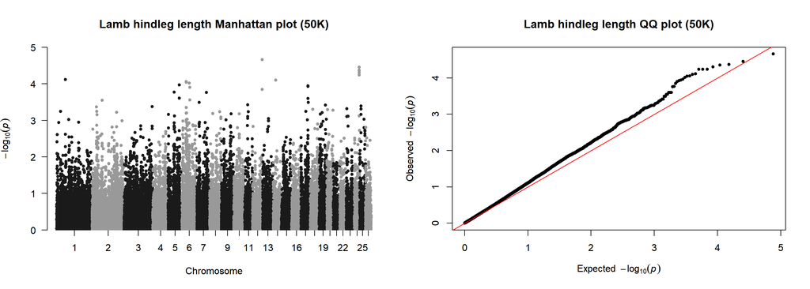

```r
files = list.files(pattern="LambHindLeg_50K_GWAS_Conditional_Chr",recursive=TRUE)

SNPresults = do.call(rbind, lapply(files, function(x) read.table(x,header=T)))
SNPresults$Effect <- SNPresults$STDEV*SNPresults$STDEV*SNPresults$BETA*SNPresults$BETA

bimFile <- read.table("C:/Users/s1944058/Documents/Sheep/50KSNP/Plates_1to87_QC3.bim",header=F)

GWAS50KResults <- merge(bimFile,SNPresults[,c("SNP","PV","Effect"),],by.x="V2",by.y="SNP",all.x=FALSE,all.y=TRUE)
colnames(GWAS50KResults) <- c("SNP","Chr","V3","Pos","Ref","Minor","PV","Effect")
GWAS50KResults$Chr <- as.numeric(GWAS50KResults$Chr)
par(mfrow=c(1,2))
manhattan(GWAS50KResults,chr="Chr",bp="Pos",p="PV",snp="SNP", main = "Lamb hindleg length Manhattan plot (50K)", genomewideline = -log10(0.05/20082),suggestiveline = FALSE)
qq(GWAS50KResults$PV,main="Lamb hindleg length QQ plot (50K)")
```

```r
SNPs <- GWAS50KResults[which(GWAS50KResults$PV < (0.05/20082) ),c("Chr","Pos","SNP","PV","Effect")]
SNPs[order(SNPs$PV),]
```

```
## [1] Chr    Pos    SNP    PV     Effect
## <0 rows> (or 0-length row.names)
```

### Imputed SNP data

> #!/bin/sh  
> #$ -cwd  
> #$ -l h_rt=3:00:00  
> #$ -pe sharedmem 1  
> #$ -l h_vmem=200G  
> #$ -t 1-26  
> #$ -tc 5  
> #$ -M s1944058@sms.ed.ac.uk  
> #$ -m baes  
> . /etc/profile.d/modules.sh

> module load igmm/apps/dissect/1.15.2c  
> module load igmm/apps/plink/1.90b4

> i=$_TASK_ID

> plink --bfile HD/Conditional_HD_Geno --sheep --not-chr ${i},X --keep LambHindlegPhenotypes.txt --make-bed --out HD/NoChr${i}

> mpirun -np 8 dissect.mpich --make-grm --bfile HD/NoChr${i} --out HD/NoChr${i}_GRM

> echo "HD/Chr${i} HD/NoChr${i}_GRM" > HD/GWAS_GRM${i}.txt

> plink --bfile HD/Conditional_HD_Geno --sheep --chr ${i} --keep LambHindlegPhenotypes.txt --make-bed --out HD/Chr${i}

> if [[ -f HD/NoChr${i}_GRM.badsnps ]]  
> then  
> plink --bfile HD/NoChr${i} --sheep --exclude HD/NoChr${i}_GRM.badsnps --make-bed --out HD/NoChr${i}_2

> mpirun -np 8 dissect.mpich --make-grm --bfile HD/NoChr${i}_2 --out HD/NoChr${i}_GRM

> fi

> mpirun -np 8 dissect.mpich --gwas --bfile-grm-list HD/GWAS_GRM${i}.txt --pheno LambHindlegPhenotypes.txt --pheno-col 2 --covar Assoc.txt --qcovar QAssoc.txt --random-effects HindlegRandom.txt --random-effects-cols 1 2 3 --out HD/LambHindLeg_HD_GWAS_Conditional_Chr${i}

> if [[ -f HD/LambHindLeg_HD_GWAS_Conditional_Chr${i}.badsnps ]]  
> then  
> plink --bfile HD/Chr${i} --sheep --exclude HD/LambHindLeg_HD_GWAS_Conditional_Chr${i}.badsnps --make-bed --out HD/Chr${i}_2

> echo "HD/Chr${i}_2 HD/NoChr${i}_GRM" > HD/GWAS_GRM${i}.txt

> mpirun -np 8 dissect.mpich --gwas --bfile-grm-list HD/GWAS_GRM${i}.txt --pheno LambHindlegPhenotypes.txt --pheno-col 2 --covar Assoc.txt --qcovar QAssoc.txt --random-effects HindlegRandom.txt --random-effects-cols 1 2 3 --out HD/LambHindLeg_HD_GWAS_Conditional_Chr${i}  
> fi

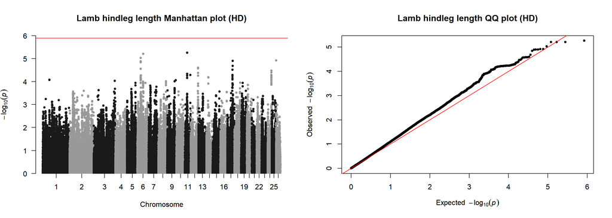

```r
files = list.files(pattern="LambHindLeg_HD_GWAS_Conditional_Chr",recursive=TRUE)

SNPresults = do.call(rbind, lapply(files, function(x) read.table(x,header=T)))
SNPresults$Effect <- SNPresults$STDEV*SNPresults$STDEV*SNPresults$BETA*SNPresults$BETA

bimFile <- read.table("C:/Users/s1944058/Documents/Sheep/HDSNP/sheep_geno_imputed_oar31_17052020.bim",header=F)

GWASHDResults <- merge(bimFile,SNPresults[,c("SNP","PV","Effect"),],by.x="V2",by.y="SNP",all.x=FALSE,all.y=TRUE)
colnames(GWASHDResults) <- c("SNP","Chr","V3","Pos","Ref","Minor","PV","Effect")
GWASHDResults$Chr <- as.numeric(GWASHDResults$Chr)
par(mfrow=c(1,2))
manhattan(GWASHDResults,chr="Chr",bp="Pos",p="PV",snp="SNP", main = "Lamb hindleg length Manhattan plot (HD)", genomewideline = -log10(0.05/39149),suggestiveline = FALSE)
qq(GWASHDResults$PV,main="Lamb hindleg length QQ plot (HD)")
```

```r
SNPs <- GWASHDResults[which(GWASHDResults$PV < (0.05/39149) ),c("Chr","Pos","SNP","PV","Effect")]
SNPs[order(SNPs$PV),]
```

```
## [1] Chr    Pos    SNP    PV     Effect
## <0 rows> (or 0-length row.names)
```

## **FINAL RESULTS**

### 50K

```r
FixedEffects_50K[6,]
```

```
##               NAME     BETA      STD
## 6 s22142.1 (Chr16) -3.90729 0.759335
```

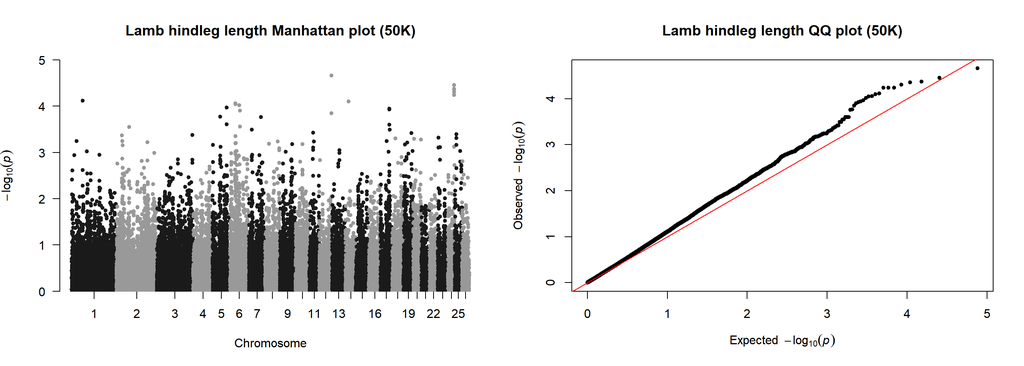

```r
par(mfrow=c(1,2))
manhattan(GWAS50KResults,chr="Chr",bp="Pos",p="PV",snp="SNP", main = "Lamb hindleg length Manhattan plot (50K)", genomewideline = -log10(0.05/20082),suggestiveline = FALSE)
qq(GWAS50KResults$PV,main="Lamb hindleg length QQ plot (50K)")
```

### HD

```r
FixedEffects_HD[6,]
```

```
##               NAME     BETA      STD
## 6 s22142.1 (Chr16) -3.92332 0.761806
```

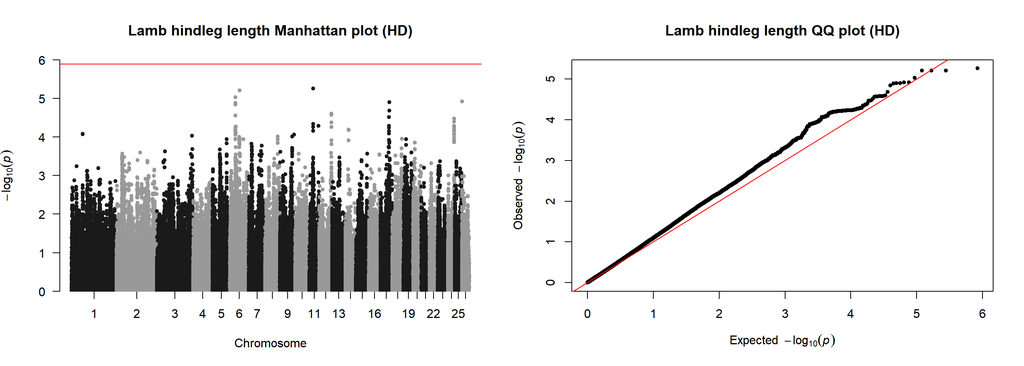

```r
par(mfrow=c(1,2))
manhattan(GWASHDResults,chr="Chr",bp="Pos",p="PV",snp="SNP", main = "Lamb hindleg length Manhattan plot (HD)", genomewideline = -log10(0.05/39149),suggestiveline = FALSE)
qq(GWASHDResults$PV,main="Lamb hindleg length QQ plot (HD)")
```